# HW06

Smirnov

04 12 2019

#Linear regression

## LOAD DATASET

Загружаем наши данные. Избавляемся от выбросов и берём log от income.

```r
data <- read.csv('zeta_nodupes.csv')
data <- subset(data, data$education < 18 & data$education > 8 & data$income < 200000 & data$income > 10000)
data$log_income <- log10(data$income)
head(data)
```

```
##        age education employment   income log_income
## 1 35.82554  10.51383  1.0616149 17110.99   4.233275
## 2 35.93574  10.69262  1.3438833 18533.84   4.267965
## 3 37.08467  11.00224  1.1538330 19545.96   4.291057
## 4 31.10425  14.26465  1.6025594 40784.49   4.610495
## 5 35.99079  10.09777  0.6287526 17496.53   4.242952
## 6 36.80649  10.85097  1.2955239 19416.41   4.288169
```

## Зависимость income от age

Тут мы видим что был построен график: y = 4.7 - 0.002x

```r
modelAge <- lm(log_income ~ age, data=data)
print(modelAge)
```

```
##
## Call:
## lm(formula = log_income ~ age, data = data)
##
## Coefficients:
## (Intercept)          age
##    4.760539    -0.002498
```

Тут мы видим параметры нашей модели, такие как t_value,P_value,R^2,F-statistic. Прочитать про них можно на http://r-statistics.co/Linear-Regression.html

```r
summary(modelAge)
```

```
##
## Call:
## lm(formula = log_income ~ age, data = data)
##
## Residuals:
##      Min       1Q   Median       3Q      Max
## -0.64718 -0.08382 -0.01615  0.07293  0.67232
##
## Coefficients:
##               Estimate Std. Error t value Pr(>|t|)
## (Intercept)  4.7605391  0.0057984  821.01   <2e-16 ***
## age         -0.0024975  0.0001457  -17.14   <2e-16 ***
## ---
## Signif. codes:  0 '***' 0.001 '**' 0.01 '*' 0.05 '.' 0.1 ' ' 1
##
## Residual standard error: 0.1387 on 31822 degrees of freedom
## Multiple R-squared:  0.009152,   Adjusted R-squared:  0.009121
## F-statistic: 293.9 on 1 and 31822 DF,  p-value: < 2.2e-16
```

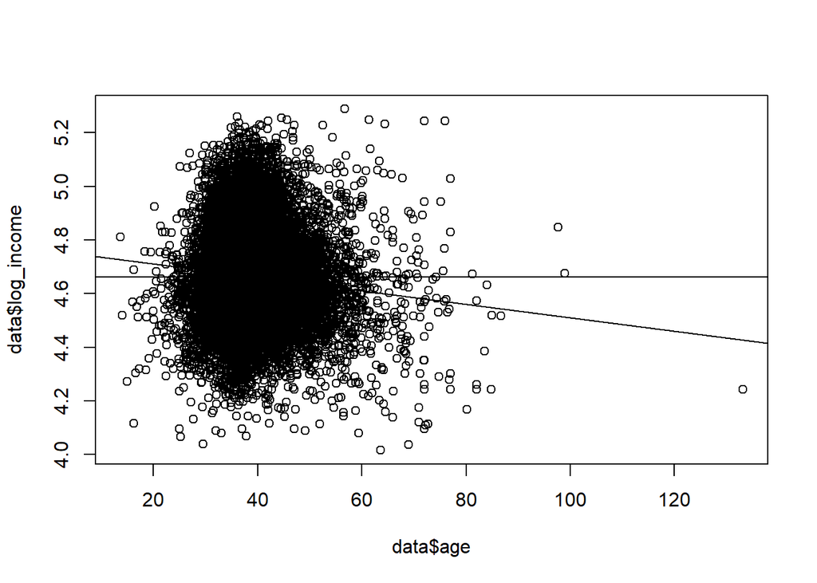

```r
plot(data$age, data$log_income)
abline(modelAge)
abline(h=mean(data$log_income))
```

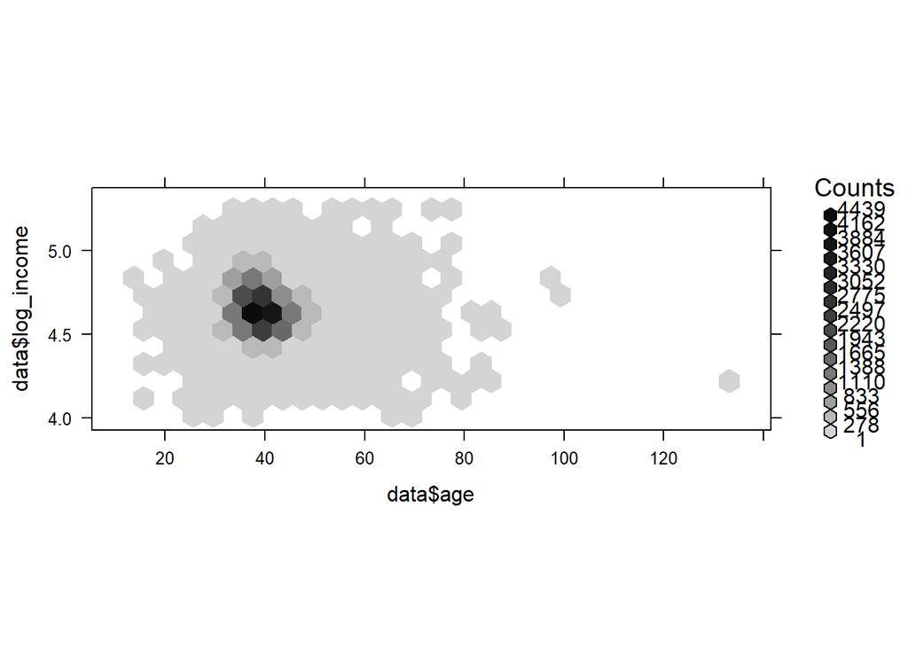

```r
library(hexbin)
hexbinplot(data$log_income ~ data$age)
```

```r
modelEducation <- lm(log_income ~ education, data=data)
print(modelEducation)
```

```
##
## Call:
## lm(formula = log_income ~ education, data = data)
##
## Coefficients:
## (Intercept)    education
##     3.53326      0.08982
```

```r
summary(modelEducation)
```

```
##
## Call:
## lm(formula = log_income ~ education, data = data)
##
## Residuals:
##      Min       1Q   Median       3Q      Max
## -0.77198 -0.05270  0.00092  0.05742  0.77991
##
## Coefficients:
##              Estimate Std. Error t value Pr(>|t|)
## (Intercept) 3.5332627  0.0058498   604.0   <2e-16 ***
## education   0.0898246  0.0004636   193.8   <2e-16 ***
## ---
## Signif. codes:  0 '***' 0.001 '**' 0.01 '*' 0.05 '.' 0.1 ' ' 1
##
## Residual standard error: 0.09435 on 31822 degrees of freedom
## Multiple R-squared:  0.5412, Adjusted R-squared:  0.5412
## F-statistic: 3.754e+04 on 1 and 31822 DF,  p-value: < 2.2e-16
```

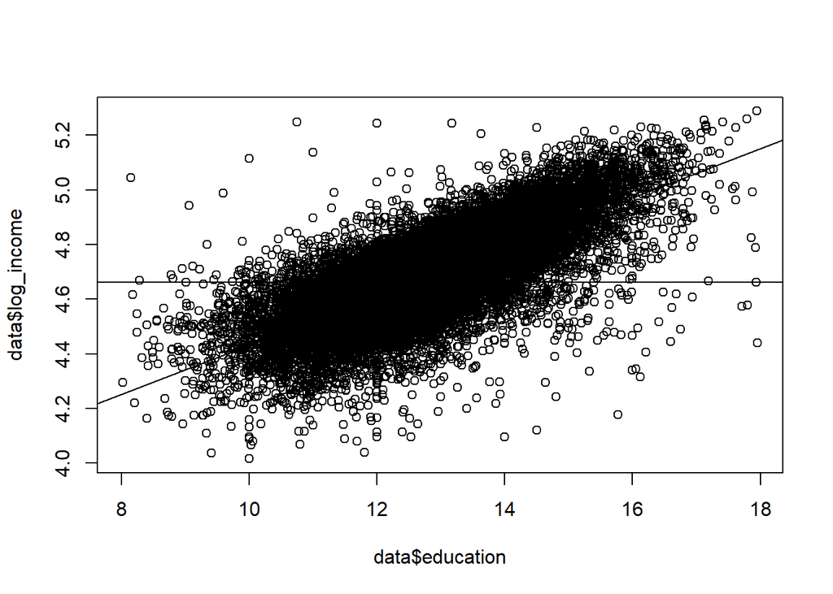

```r
plot(data$education, data$log_income)
abline(modelEducation)
abline(h=mean(data$log_income))
```

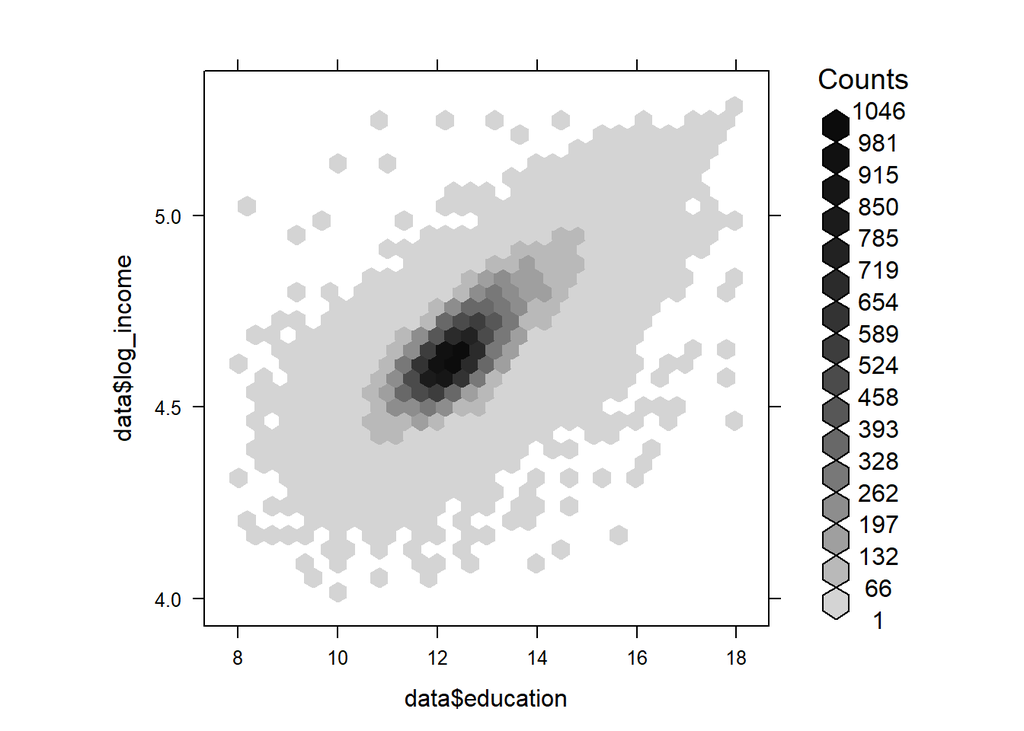

```r
hexbinplot(data$log_income ~ data$education)
```

# Multiple regression model

```r
multipleModel <- lm(log_income ~ age + education + employment, data=data)
print(multipleModel)
```

```
##
## Call:
## lm(formula = log_income ~ age + education + employment, data = data)
##
## Coefficients:
## (Intercept)          age    education   employment
##    3.573045    -0.001501     0.081505     0.066397
```

```r
summary(multipleModel)
```

```
##
## Call:
## lm(formula = log_income ~ age + education + employment, data = data)
##
## Residuals:
##      Min       1Q   Median       3Q      Max
## -0.80486 -0.04900 -0.00013  0.05090  0.83007
##
## Coefficients:
##               Estimate Std. Error t value Pr(>|t|)
## (Intercept)  3.5730450  0.0068179  524.07   <2e-16 ***
## age         -0.0015010  0.0001025  -14.64   <2e-16 ***
## education    0.0815053  0.0004837  168.52   <2e-16 ***
## employment   0.0663974  0.0014581   45.54   <2e-16 ***
## ---
## Signif. codes:  0 '***' 0.001 '**' 0.01 '*' 0.05 '.' 0.1 ' ' 1
##
## Residual standard error: 0.0898 on 31820 degrees of freedom
## Multiple R-squared:  0.5844, Adjusted R-squared:  0.5844
## F-statistic: 1.492e+04 on 3 and 31820 DF,  p-value: < 2.2e-16
```

Residuals vs.Fitted: you want to make sure that the errors are evenly distributed over the entire range of fitted values; if the errors are markedly larger (or biased either positively or negatively) in some range of the data, this is evidence that this model may not be entirely appropriate for the problem.

Q-Q plot: tests whether or not the errors are in fact distributed approximately normally (as the model formulation assumes). If they are, the Q-Q plot will be along the x=y line. If they aren’t, the model may still be adequate, but perhaps a more robust modeling method is suitable. Also, the usual diagnostics (R-squared, t-tests for significance) will not be valid.

Scale-Location: a similar idea to Residuals v. Fitted; you want to make sure that the variance (or its stand-in, “scale”) is approximately constantover the range of fitted values.

Residuals vs.Leverage: used for identifying potential outliers and “influential” points. Points that are far from the centroid of the scatterplot in the x direction (high leverage) are influential, in the sense that they may have disproportionate influence on the fit (that doesn’t mean they are wrong, necessarily). Points that are far from the centroid in the y direction (large residuals) are potential outliers.

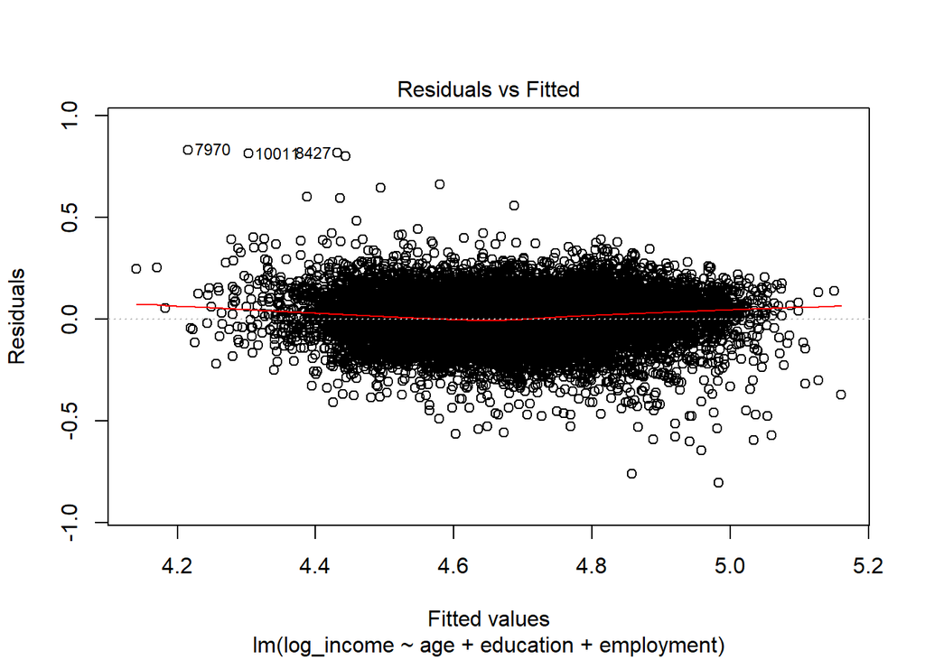

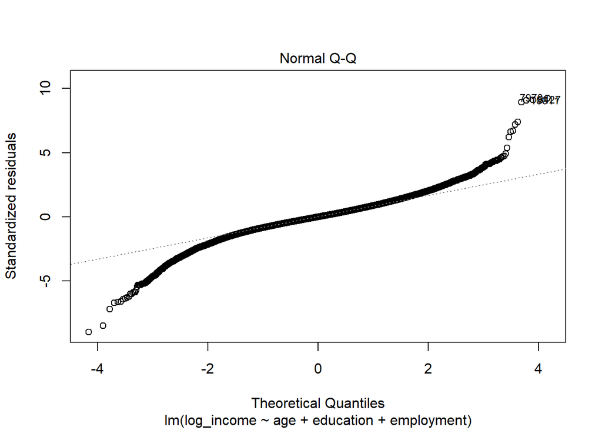

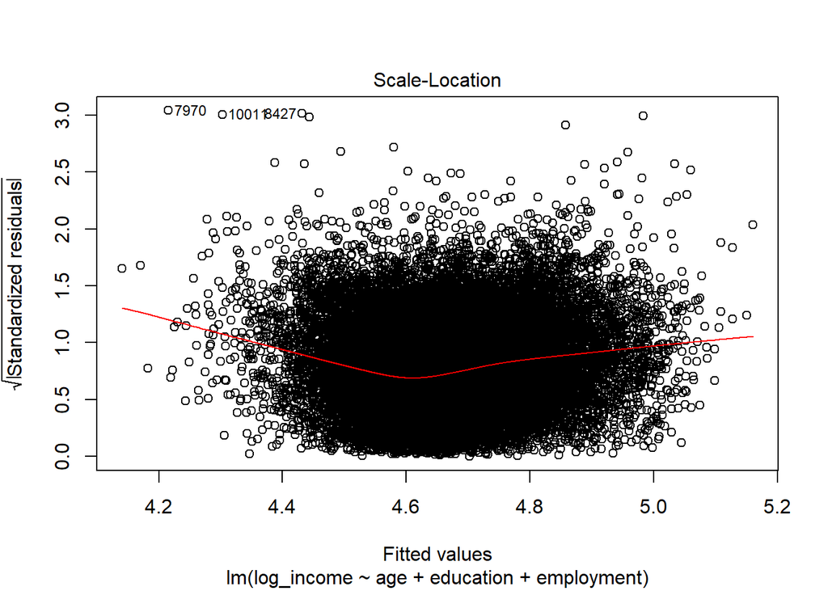

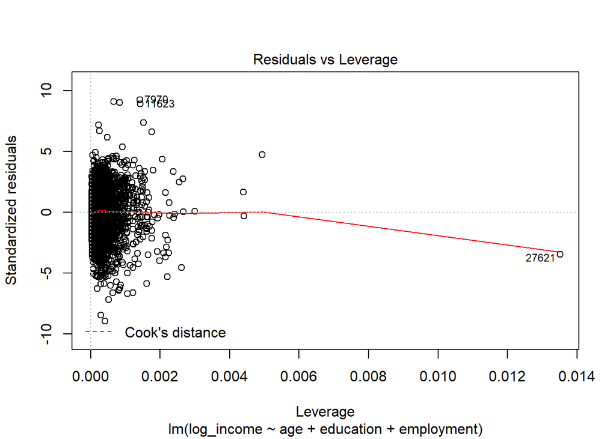

```r
plot(multipleModel)
```

```r
testData <- data.frame (age= c(3,3,4,4), education = c(5,6,9,10), employment = c(4,4,9,9))
logPredictions <- predict(multipleModel,newdata=testData,type="response")
logPredictions
```

```
##        1        2        3        4
## 4.241658 4.323163 4.898165 4.979670
```

```r
predictions <- 10**logPredictions
```